# Factors Affecting Yield (Project for final assessment for Statistical Methods II)

Helen Solecki - hs952

2025-05-12

```r
#loading the data
dat <- read.csv("C:\\Users\\hs952\\Box\\Stats2\\ag_yields.csv")
```

### Introduction

*Exploratory Data Analysis*

```r
library(ggplot2)
head(dat)
```

|  | Soil_Quality | Fertilizer_Amount_kg_per_hectare | Sunny_Days | Rainfall_mm | Irrigation_Schedule | Yield_kg_per_hectare |
| --- | --- | --- | --- | --- | --- | --- |
| 1 | 93.30472 | 132.5222 | 96.67092 | 602.3862 | 3 | 278.9866 |
| 2 | 83.67465 | 57.2840 | 99.00756 | 466.5183 | 8 | 836.4348 |
| 3 | 65.96303 | 227.8955 | 104.84427 | 510.3205 | 4 | 785.8818 |
| 4 | 78.69283 | 176.3141 | 90.13619 | 354.3509 | 5 | 807.8845 |
| 5 | 72.41568 | 160.0704 | 101.22167 | 443.9938 | 10 | 1064.5424 |
| 6 | 62.69708 | 268.4394 | 99.97071 | 485.2231 | 8 | 1003.2294 |

```r
str(dat)
```

```
## 'data.frame':    4000 obs. of  6 variables:
##  $ Soil_Quality                    : num  93.3 83.7 66 78.7 72.4 ...
##  $ Fertilizer_Amount_kg_per_hectare: num  132.5 57.3 227.9 176.3 160.1 ...
##  $ Sunny_Days                      : num  96.7 99 104.8 90.1 101.2 ...
##  $ Rainfall_mm                     : num  602 467 510 354 444 ...
##  $ Irrigation_Schedule             : int  3 8 4 5 10 8 2 3 4 6 ...
##  $ Yield_kg_per_hectare            : num  279 836 786 808 1065 ...
```

```r
dim(dat)
```

```
## [1] 4000    6
```

```r
print(summary(dat))
```

```
##   Soil_Quality    Fertilizer_Amount_kg_per_hectare   Sunny_Days
##  Min.   : 50.00   Min.   : 50.06                   Min.   : 66.72
##  1st Qu.: 62.38   1st Qu.:108.73                   1st Qu.: 93.10
##  Median : 74.63   Median :175.60                   Median : 99.76
##  Mean   : 74.92   Mean   :173.45                   Mean   : 99.84
##  3rd Qu.: 87.79   3rd Qu.:235.20                   3rd Qu.:106.45
##  Max.   :100.00   Max.   :299.99                   Max.   :138.52
##   Rainfall_mm    Irrigation_Schedule Yield_kg_per_hectare
##  Min.   :102.0   Min.   : 0.000      Min.   : 108.3
##  1st Qu.:435.8   1st Qu.: 3.000      1st Qu.: 576.4
##  Median :502.9   Median : 5.000      Median : 722.5
##  Mean   :502.2   Mean   : 4.978      Mean   : 709.2
##  3rd Qu.:568.2   3rd Qu.: 6.000      3rd Qu.: 847.8
##  Max.   :876.7   Max.   :15.000      Max.   :1406.1
```

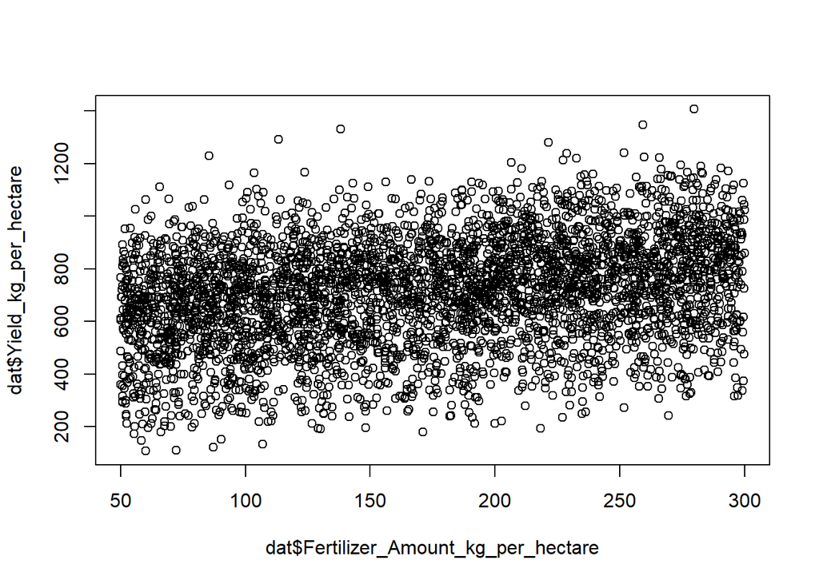

```r
plot(dat$Fertilizer_Amount_kg_per_hectare, dat$Yield_kg_per_hectare)
```

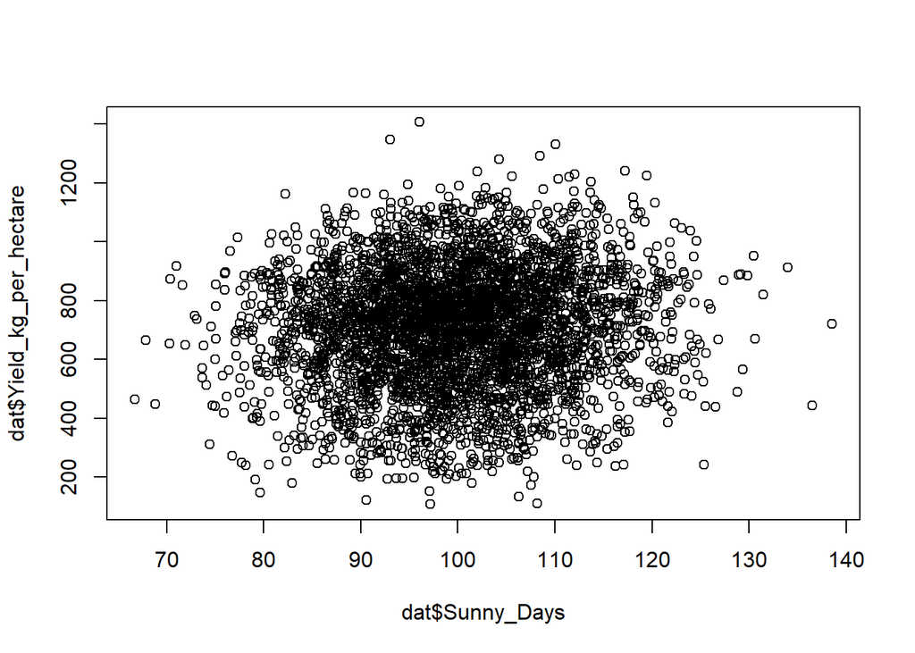

```r
plot(dat$Sunny_Days, dat$Yield_kg_per_hectare)
```

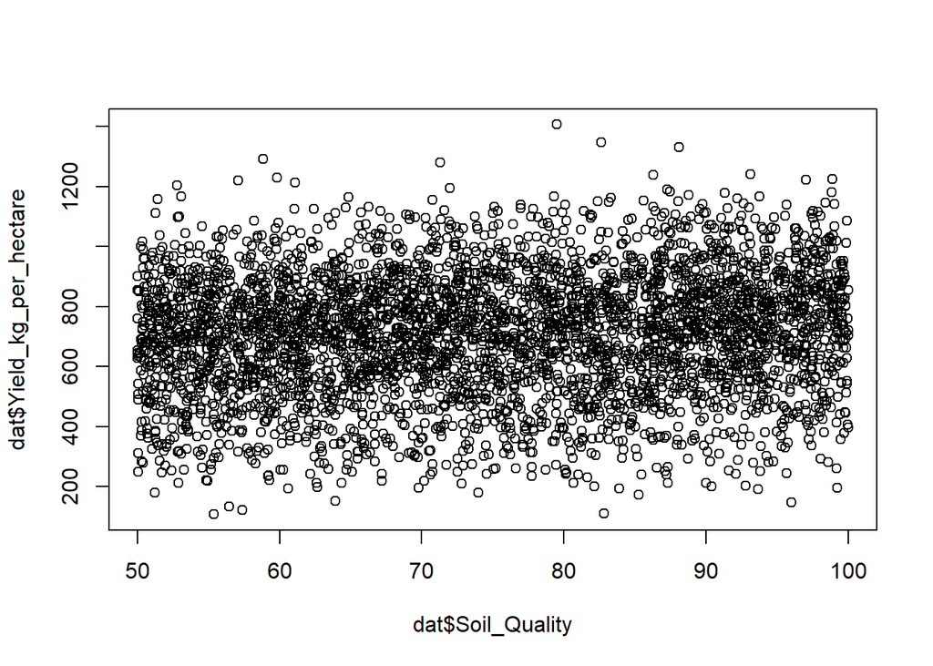

```r
plot(dat$Soil_Quality, dat$Yield_kg_per_hectare)
```

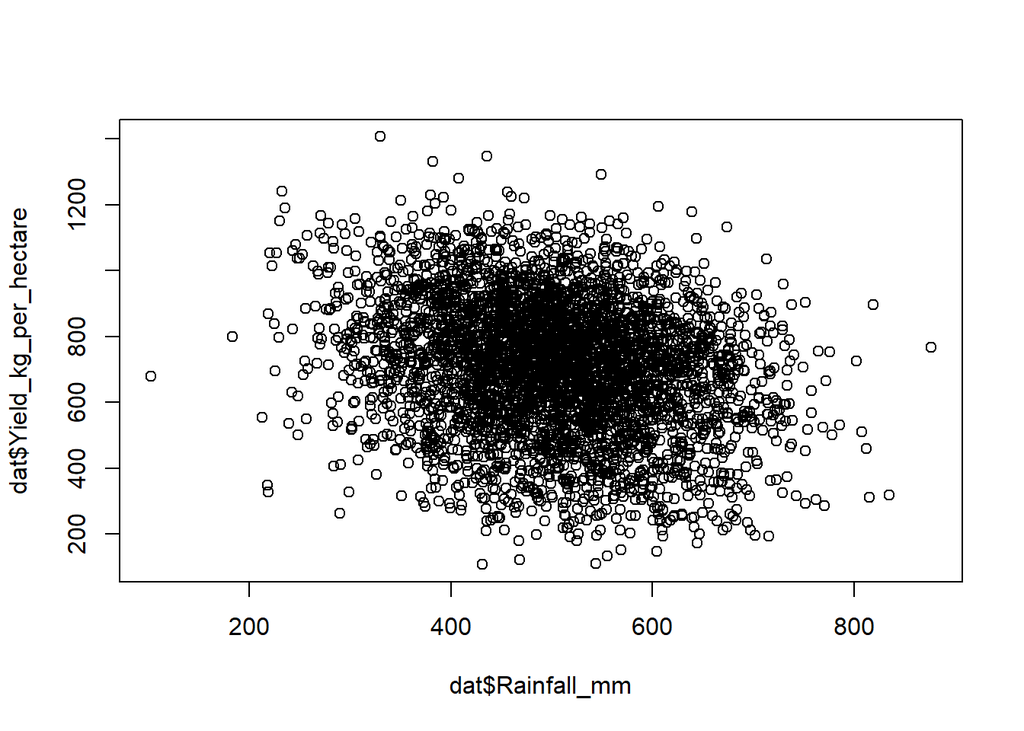

```r
plot(dat$Rainfall_mm, dat$Yield_kg_per_hectare)
```

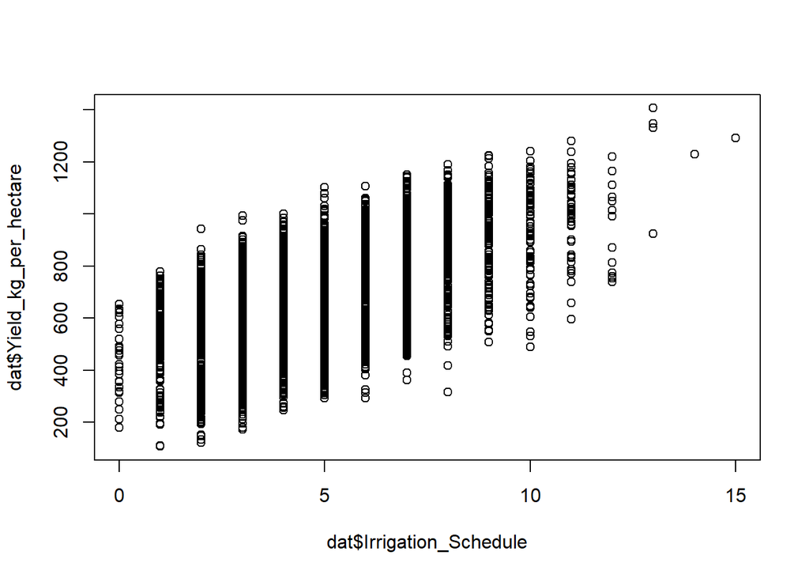

```r
plot(dat$Irrigation_Schedule, dat$Yield_kg_per_hectare)
```

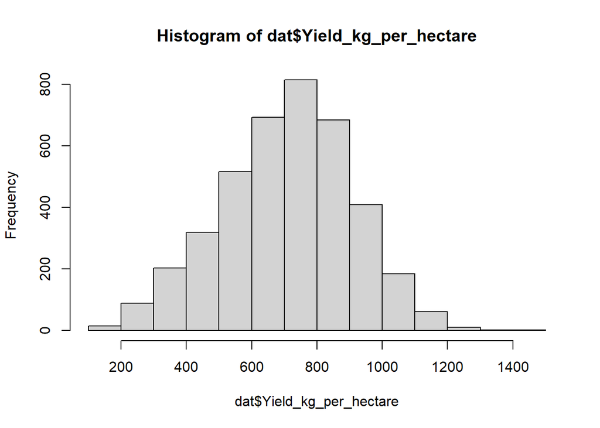

```r
hist(dat$Yield_kg_per_hectare)
```

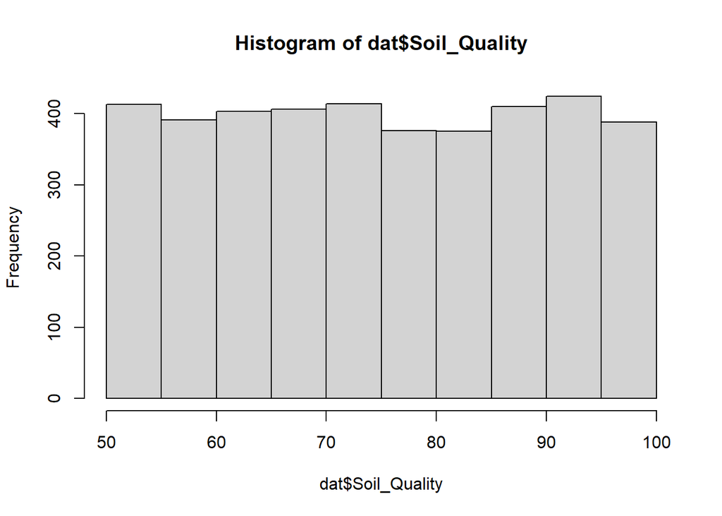

```r
hist(dat$Soil_Quality)
```

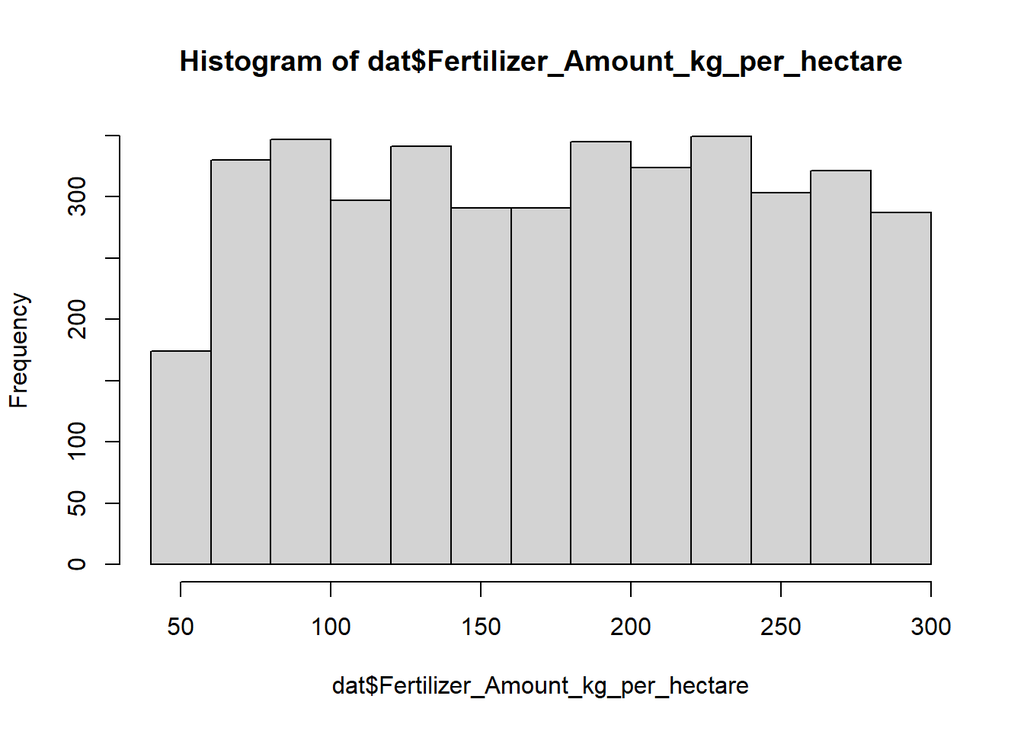

```r
hist(dat$Fertilizer_Amount_kg_per_hectare)
```

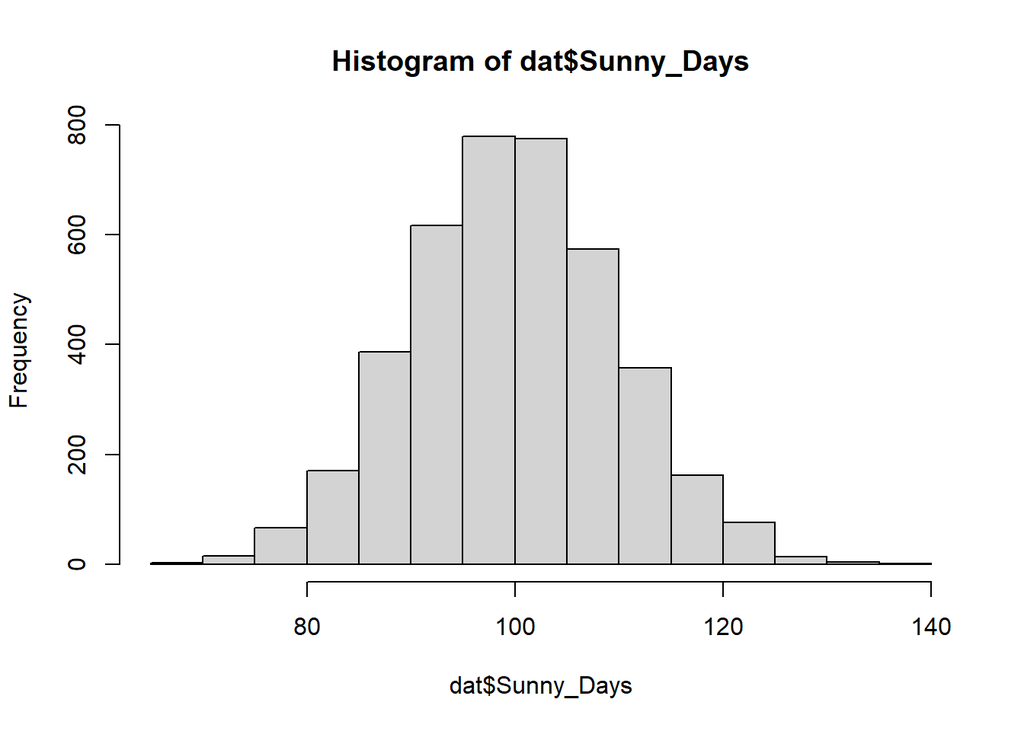

```r
hist(dat$Sunny_Days)
```

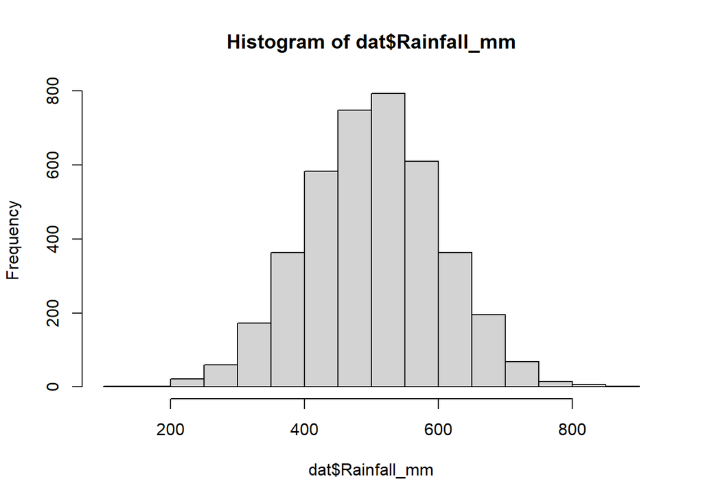

```r
hist(dat$Rainfall_mm)
```

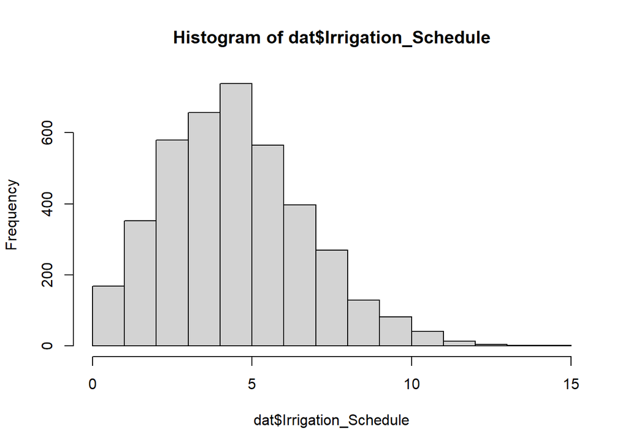

```r
hist(dat$Irrigation_Schedule)
```

This dataset shows crop yield in kg/hectare, along with a numeric index of soil quality, the amount of fertilizer in kg/hectare, the number of sunny days in the growing season, rainfall in mm, and the number of irrigations in the growing season. There are 6 variables and 4,000 observations. Here, I sought to assess predictors of yield, since it is such an important metric in agriculture. By identifying which factors are the most important and why, farmers can make decisions on how to prioritize their resources. Based on quick summary statistics, there do not appear to be obvious significant outliers in scatterplots, and there are possibly some linear trends that can be explored. Yield and sunny days appear to be distributed fairly normally. Irrigation schedule has a slight right skew. All data can be handled numerically. The summary() function prints and reports for us the min, max, median, 1st and 3rd quartile for each variable. For this dataset, average yield was 709.2.

```r
#linear model
library("sandwich")
library("lmtest")
library("lme4")
library("lmboot")
library("car")
head(dat)
```

|  | Soil_Quality | Fertilizer_Amount_kg_per_hectare | Sunny_Days | Rainfall_mm | Irrigation_Schedule | Yield_kg_per_hectare |
| --- | --- | --- | --- | --- | --- | --- |
| 1 | 93.30472 | 132.5222 | 96.67092 | 602.3862 | 3 | 278.9866 |
| 2 | 83.67465 | 57.2840 | 99.00756 | 466.5183 | 8 | 836.4348 |
| 3 | 65.96303 | 227.8955 | 104.84427 | 510.3205 | 4 | 785.8818 |
| 4 | 78.69283 | 176.3141 | 90.13619 | 354.3509 | 5 | 807.8845 |
| 5 | 72.41568 | 160.0704 | 101.22167 | 443.9938 | 10 | 1064.5424 |
| 6 | 62.69708 | 268.4394 | 99.97071 | 485.2231 | 8 | 1003.2294 |

```r
mod_full <- lm(Yield_kg_per_hectare ~ Soil_Quality + Fertilizer_Amount_kg_per_hectare + Sunny_Days + Rainfall_mm + Irrigation_Schedule, data = dat)
summary(mod_full)
```

```
##
## Call:
## lm(formula = Yield_kg_per_hectare ~ Soil_Quality + Fertilizer_Amount_kg_per_hectare +
##     Sunny_Days + Rainfall_mm + Irrigation_Schedule, data = dat)
##
## Residuals:
##     Min      1Q  Median      3Q     Max
## -383.72 -159.03   59.38  106.77  300.54
##
## Coefficients:
##                                   Estimate Std. Error t value Pr(>|t|)
## (Intercept)                      293.87564   29.68156   9.901  < 2e-16 ***
## Soil_Quality                       1.43979    0.15899   9.056  < 2e-16 ***
## Fertilizer_Amount_kg_per_hectare   0.78999    0.03189  24.774  < 2e-16 ***
## Sunny_Days                         1.58724    0.23310   6.809 1.13e-11 ***
## Rainfall_mm                       -0.46469    0.02323 -20.008  < 2e-16 ***
## Irrigation_Schedule               49.28403    1.01979  48.328  < 2e-16 ***
## ---
## Signif. codes:  0 '***' 0.001 '**' 0.01 '*' 0.05 '.' 0.1 ' ' 1
##
## Residual standard error: 145.7 on 3994 degrees of freedom
## Multiple R-squared:  0.4671, Adjusted R-squared:  0.4665
## F-statistic: 700.3 on 5 and 3994 DF,  p-value: < 2.2e-16
```

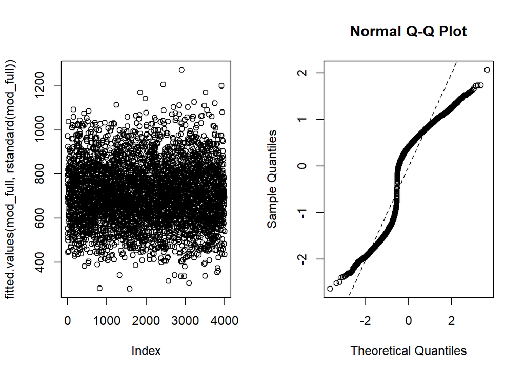

```r
#residuals vs fitted
par(mfrow = c(1,2))
plot(fitted.values(mod_full,rstandard(mod_full)))
abline(h=0)
#normal Q-Q
qqnorm(rstandard(mod_full))
abline(0,1,lty=2)
```

```r
#bp test for homoscedasticity
bptest(mod_full)
```

```
##
##  studentized Breusch-Pagan test
##
## data:  mod_full
## BP = 2.7024, df = 5, p-value = 0.7457
```

```r
#multicollinearity
vif(mod_full)
```

```
##                     Soil_Quality Fertilizer_Amount_kg_per_hectare
##                         1.000443                         1.000966
##                       Sunny_Days                      Rainfall_mm
##                         1.000605                         1.000120
##              Irrigation_Schedule
##                         1.000179
```

```r
#durbin watson
durbinWatsonTest(mod_full)
```

```
##  lag Autocorrelation D-W Statistic p-value
##    1     0.005167907      1.987829    0.73
##  Alternative hypothesis: rho != 0
```

### Methodology

*Assumptions verification and assumptions handling*

After creating a linear model for the data, we must check that the assumptions for the model are met. The key assumptions for the linear model are: linearity, independence, homoscedasticity, normality, and low multicollinearity.

To test for normality, I created a Q-Q plot of the residuals. The curve does not fall completely on a straight line. I attempted to apply transformations to the data, especially to the Soil Quality and Fertilizer variables as the histograms for these variables did not appear normally distributed in the data summary. I also attempted to transform irrigation schedule since this distribution was skewed. Transformation such as log, natural log, or squaring can sometimes normalize the data. I was not able to apply a transformation that would make the Q-Q plot follow a straight line completely. That being said, the curve is not extreme. Ordinary Least Squares estimates can still be reliable but small-sample testing such as with t or F tests may be invalid or unreliable. The tests can still be performed, but we should pay extra attention to highly significant p-value and take caution when generalizing.

To statistically test for homoscedasticity I used the Bruesch-Pagan Test to determine if residuals are distributed with equal variance. With a p-value of 0.7457, we cannot reject the null hypothesis that there is homoscedasticity. Hence, it’s safe to say the data is not heteroscedastic.

I also tested statistically for multicollinearity using the vif() function. With all values below 5, I can conclude that there is not multicollinearity in the dataset.

I used a durbin-watson test to statistically determine independence. With a D-W statistic of 1.98, we can conclude that there is not autocorrelation of the residuals, providing further evidence that the independence violation is not violated.

*Variable selection techniques: Forward and backward selection with BIC*

```r
#forward selection with BIC
#smallest model
intOnly <- lm(Yield_kg_per_hectare ~ 1, data=dat)
#largest model
largest <- lm(Yield_kg_per_hectare ~ ., data=dat)
out_forward_bic <- step(object = intOnly, direction = "forward", scope = formula(largest), trace = T, k = log(nrow(dat)))
```

```
## Start:  AIC=42373.71
## Yield_kg_per_hectare ~ 1
##
##                                    Df Sum of Sq       RSS   AIC
## + Irrigation_Schedule               1  50015290 109142114 40873
## + Fertilizer_Amount_kg_per_hectare  1  13192944 145964460 42036
## + Rainfall_mm                       1   8983028 150174377 42150
## + Soil_Quality                      1   1629062 157528342 42341
## + Sunny_Days                        1   1006998 158150406 42357
## <none>                                          159157404 42374
##
## Step:  AIC=40873.04
## Yield_kg_per_hectare ~ Irrigation_Schedule
##
##                                    Df Sum of Sq       RSS   AIC
## + Fertilizer_Amount_kg_per_hectare  1  13124572  96017543 40369
## + Rainfall_mm                       1   8598154 100543960 40553
## + Soil_Quality                      1   1548160 107593955 40824
## + Sunny_Days                        1   1131220 108010895 40840
## <none>                                          109142114 40873
##
## Step:  AIC=40368.85
## Yield_kg_per_hectare ~ Irrigation_Schedule + Fertilizer_Amount_kg_per_hectare
##
##                Df Sum of Sq      RSS   AIC
## + Rainfall_mm   1   8487229 87530314 40007
## + Soil_Quality  1   1738616 94278927 40304
## + Sunny_Days    1    962852 95054691 40337
## <none>                      96017543 40369
##
## Step:  AIC=40006.96
## Yield_kg_per_hectare ~ Irrigation_Schedule + Fertilizer_Amount_kg_per_hectare +
##     Rainfall_mm
##
##                Df Sum of Sq      RSS   AIC
## + Soil_Quality  1   1735746 85794567 39935
## + Sunny_Days    1    979006 86551308 39970
## <none>                      87530314 40007
##
## Step:  AIC=39935.14
## Yield_kg_per_hectare ~ Irrigation_Schedule + Fertilizer_Amount_kg_per_hectare +
##     Rainfall_mm + Soil_Quality
##
##              Df Sum of Sq      RSS   AIC
## + Sunny_Days  1    984547 84810020 39897
## <none>                    85794567 39935
##
## Step:  AIC=39897.26
## Yield_kg_per_hectare ~ Irrigation_Schedule + Fertilizer_Amount_kg_per_hectare +
##     Rainfall_mm + Soil_Quality + Sunny_Days
```

```r
summary(out_forward_bic)
```

```
##
## Call:
## lm(formula = Yield_kg_per_hectare ~ Irrigation_Schedule + Fertilizer_Amount_kg_per_hectare +
##     Rainfall_mm + Soil_Quality + Sunny_Days, data = dat)
##
## Residuals:
##     Min      1Q  Median      3Q     Max
## -383.72 -159.03   59.38  106.77  300.54
##
## Coefficients:
##                                   Estimate Std. Error t value Pr(>|t|)
## (Intercept)                      293.87564   29.68156   9.901  < 2e-16 ***
## Irrigation_Schedule               49.28403    1.01979  48.328  < 2e-16 ***
## Fertilizer_Amount_kg_per_hectare   0.78999    0.03189  24.774  < 2e-16 ***
## Rainfall_mm                       -0.46469    0.02323 -20.008  < 2e-16 ***
## Soil_Quality                       1.43979    0.15899   9.056  < 2e-16 ***
## Sunny_Days                         1.58724    0.23310   6.809 1.13e-11 ***
## ---
## Signif. codes:  0 '***' 0.001 '**' 0.01 '*' 0.05 '.' 0.1 ' ' 1
##
## Residual standard error: 145.7 on 3994 degrees of freedom
## Multiple R-squared:  0.4671, Adjusted R-squared:  0.4665
## F-statistic: 700.3 on 5 and 3994 DF,  p-value: < 2.2e-16
```

```r
#backward selection with BIC
out_backward_bic <- step(object = largest, direction = "backward",
scope = formula(largest), trace = T, k = log(nrow(dat)))
```

```
## Start:  AIC=39897.26
## Yield_kg_per_hectare ~ Soil_Quality + Fertilizer_Amount_kg_per_hectare +
##     Sunny_Days + Rainfall_mm + Irrigation_Schedule
##
##                                    Df Sum of Sq       RSS   AIC
## <none>                                           84810020 39897
## - Sunny_Days                        1    984547  85794567 39935
## - Soil_Quality                      1   1741288  86551308 39970
## - Rainfall_mm                       1   8500551  93310572 40271
## - Fertilizer_Amount_kg_per_hectare  1  13032733  97842753 40461
## - Irrigation_Schedule               1  49594376 134404396 41731
```

```r
summary(out_backward_bic)
```

```
##
## Call:
## lm(formula = Yield_kg_per_hectare ~ Soil_Quality + Fertilizer_Amount_kg_per_hectare +
##     Sunny_Days + Rainfall_mm + Irrigation_Schedule, data = dat)
##
## Residuals:
##     Min      1Q  Median      3Q     Max
## -383.72 -159.03   59.38  106.77  300.54
##
## Coefficients:
##                                   Estimate Std. Error t value Pr(>|t|)
## (Intercept)                      293.87564   29.68156   9.901  < 2e-16 ***
## Soil_Quality                       1.43979    0.15899   9.056  < 2e-16 ***
## Fertilizer_Amount_kg_per_hectare   0.78999    0.03189  24.774  < 2e-16 ***
## Sunny_Days                         1.58724    0.23310   6.809 1.13e-11 ***
## Rainfall_mm                       -0.46469    0.02323 -20.008  < 2e-16 ***
## Irrigation_Schedule               49.28403    1.01979  48.328  < 2e-16 ***
## ---
## Signif. codes:  0 '***' 0.001 '**' 0.01 '*' 0.05 '.' 0.1 ' ' 1
##
## Residual standard error: 145.7 on 3994 degrees of freedom
## Multiple R-squared:  0.4671, Adjusted R-squared:  0.4665
## F-statistic: 700.3 on 5 and 3994 DF,  p-value: < 2.2e-16
```

In order to identify the strongest and simplest model to predict yield (the most parsimonious), I used two different selection techniques: forward and backward with BIC. The results of forward and backward selection with BIC generated the same result: a linear model with all included covariates, aka the full original model which takes into account soil quality, fertilizer, sunny days, rainfall, and irrigation. This model is both the most predictive and simplest. If the backward and forward selection had given different results, I would pick the one which has the smaller AIC value which would be the most parsimonious.

*Hypothesis testing*

I decided to use the full model to test the significance of one covariate within the model. Here I would like to look at the significance of the effect of soil quality after conditioning for all other covariates. I chose soil quality because this is one of the factors that can be altered with soil health practices like reduced tillage or cover cropping. Insight into how soil quality plays a role could help determine to what extent soil management practices matter in regards to yield. The null hypothesis is that soil quality is not associated with yield, and the alternative hypothesis is that soil quality is associated with yield. I used alpha level 0.05.

```r
#model to test
mod_full <- lm(Yield_kg_per_hectare ~ Soil_Quality + Fertilizer_Amount_kg_per_hectare + Sunny_Days + Rainfall_mm + Irrigation_Schedule, data = dat)
summary(mod_full)
```

```
##
## Call:
## lm(formula = Yield_kg_per_hectare ~ Soil_Quality + Fertilizer_Amount_kg_per_hectare +
##     Sunny_Days + Rainfall_mm + Irrigation_Schedule, data = dat)
##
## Residuals:
##     Min      1Q  Median      3Q     Max
## -383.72 -159.03   59.38  106.77  300.54
##
## Coefficients:
##                                   Estimate Std. Error t value Pr(>|t|)
## (Intercept)                      293.87564   29.68156   9.901  < 2e-16 ***
## Soil_Quality                       1.43979    0.15899   9.056  < 2e-16 ***
## Fertilizer_Amount_kg_per_hectare   0.78999    0.03189  24.774  < 2e-16 ***
## Sunny_Days                         1.58724    0.23310   6.809 1.13e-11 ***
## Rainfall_mm                       -0.46469    0.02323 -20.008  < 2e-16 ***
## Irrigation_Schedule               49.28403    1.01979  48.328  < 2e-16 ***
## ---
## Signif. codes:  0 '***' 0.001 '**' 0.01 '*' 0.05 '.' 0.1 ' ' 1
##
## Residual standard error: 145.7 on 3994 degrees of freedom
## Multiple R-squared:  0.4671, Adjusted R-squared:  0.4665
## F-statistic: 700.3 on 5 and 3994 DF,  p-value: < 2.2e-16
```

The t-statistic for the hypothesis test is t=9.056. The p-value is 2e-16, which is much less than 0.05. This tells us to reject the null hypothesis that there is no association between soil quality and yield. This means that there is indeed an association between soil quality and yield.

*Assessing the model and validating the model with cross validation*

```r
mod_full <- lm(Yield_kg_per_hectare ~ Soil_Quality + Fertilizer_Amount_kg_per_hectare + Sunny_Days + Rainfall_mm + Irrigation_Schedule, data = dat)
summary(mod_full)
```

```
##
## Call:
## lm(formula = Yield_kg_per_hectare ~ Soil_Quality + Fertilizer_Amount_kg_per_hectare +
##     Sunny_Days + Rainfall_mm + Irrigation_Schedule, data = dat)
##
## Residuals:
##     Min      1Q  Median      3Q     Max
## -383.72 -159.03   59.38  106.77  300.54
##
## Coefficients:
##                                   Estimate Std. Error t value Pr(>|t|)
## (Intercept)                      293.87564   29.68156   9.901  < 2e-16 ***
## Soil_Quality                       1.43979    0.15899   9.056  < 2e-16 ***
## Fertilizer_Amount_kg_per_hectare   0.78999    0.03189  24.774  < 2e-16 ***
## Sunny_Days                         1.58724    0.23310   6.809 1.13e-11 ***
## Rainfall_mm                       -0.46469    0.02323 -20.008  < 2e-16 ***
## Irrigation_Schedule               49.28403    1.01979  48.328  < 2e-16 ***
## ---
## Signif. codes:  0 '***' 0.001 '**' 0.01 '*' 0.05 '.' 0.1 ' ' 1
##
## Residual standard error: 145.7 on 3994 degrees of freedom
## Multiple R-squared:  0.4671, Adjusted R-squared:  0.4665
## F-statistic: 700.3 on 5 and 3994 DF,  p-value: < 2.2e-16
```

After our selection techniques and hypothesis testing, we have determined that the full model is indeed both the simplest and the best fit. RMSE is 145.7 on 3994 degrees of freedom, with a p-value of <2.2e-16. The R squared for the chosen model indicates that about 47% of the variance in Yield can be explained by the model.The value is approximately the same for multiple and adjusted R-Squared. Adjusted R-squared penalizes for overfitting, so the fact that they are the same suggests that over-fitting is not a concern here.The RMSE indicates that average error of the model is 145.7 which is reasonable considering the mean yield of 709.2. Degrees of freedom accounts the 4000 observations and subtracts the number of predictors to get to 3994.

I sought to validate how our model might do with new data. Below, I used the glm and cv.glm functions to implement K-fold cross validation where k=5 to evaluate prediction error for the full model. The cv.glm function separates the data into K sets and the glm is fit for each group, then compared to a prediction based on the remaining set as a test set. The function outputs a delta prediction error to demonstrate the fit of the model.

```r
#kfold CV for full model lab 8
library("boot")
cv_mod <- glm(Yield_kg_per_hectare ~ Soil_Quality + Fertilizer_Amount_kg_per_hectare + Sunny_Days + Rainfall_mm + Irrigation_Schedule, data = dat)
summary(cv_mod)
```

```
##
## Call:
## glm(formula = Yield_kg_per_hectare ~ Soil_Quality + Fertilizer_Amount_kg_per_hectare +
##     Sunny_Days + Rainfall_mm + Irrigation_Schedule, data = dat)
##
## Coefficients:
##                                   Estimate Std. Error t value Pr(>|t|)
## (Intercept)                      293.87564   29.68156   9.901  < 2e-16 ***
## Soil_Quality                       1.43979    0.15899   9.056  < 2e-16 ***
## Fertilizer_Amount_kg_per_hectare   0.78999    0.03189  24.774  < 2e-16 ***
## Sunny_Days                         1.58724    0.23310   6.809 1.13e-11 ***
## Rainfall_mm                       -0.46469    0.02323 -20.008  < 2e-16 ***
## Irrigation_Schedule               49.28403    1.01979  48.328  < 2e-16 ***
## ---
## Signif. codes:  0 '***' 0.001 '**' 0.01 '*' 0.05 '.' 0.1 ' ' 1
##
## (Dispersion parameter for gaussian family taken to be 21234.36)
##
##     Null deviance: 159157404  on 3999  degrees of freedom
## Residual deviance:  84810020  on 3994  degrees of freedom
## AIC: 51213
##
## Number of Fisher Scoring iterations: 2
```

```r
err_cv <- cv.glm(dat, cv_mod, K=5)
err_cv
```

[output not shown]

[output cut: 100 more lines]

```r
#kfold CV for model without soil quality
library("boot")
cv_mod_nosoil <- glm(Yield_kg_per_hectare ~ Fertilizer_Amount_kg_per_hectare + Sunny_Days + Rainfall_mm + Irrigation_Schedule, data = dat)
summary(cv_mod_nosoil)
```

```
##
## Call:
## glm(formula = Yield_kg_per_hectare ~ Fertilizer_Amount_kg_per_hectare +
##     Sunny_Days + Rainfall_mm + Irrigation_Schedule, data = dat)
##
## Coefficients:
##                                   Estimate Std. Error t value Pr(>|t|)
## (Intercept)                      403.04953   27.39643  14.712  < 2e-16 ***
## Fertilizer_Amount_kg_per_hectare   0.78410    0.03220  24.349  < 2e-16 ***
## Sunny_Days                         1.58276    0.23545   6.722 2.04e-11 ***
## Rainfall_mm                       -0.46477    0.02346 -19.812  < 2e-16 ***
## Irrigation_Schedule               49.32602    1.03006  47.886  < 2e-16 ***
## ---
## Signif. codes:  0 '***' 0.001 '**' 0.01 '*' 0.05 '.' 0.1 ' ' 1
##
## (Dispersion parameter for gaussian family taken to be 21664.91)
##
##     Null deviance: 159157404  on 3999  degrees of freedom
## Residual deviance:  86551308  on 3995  degrees of freedom
## AIC: 51292
##
## Number of Fisher Scoring iterations: 2
```

```r
err_cv <- cv.glm(dat, cv_mod_nosoil, K=5)
err_cv
```

[output not shown]

[output cut: 100 more lines]

### Results and Discussion

*Feature impacts analysis: features, confidence intervals, implications*

```r
mod_full <- lm(Yield_kg_per_hectare ~ Soil_Quality + Fertilizer_Amount_kg_per_hectare + Sunny_Days + Rainfall_mm + Irrigation_Schedule, data = dat)
summary(mod_full)
```

```
##
## Call:
## lm(formula = Yield_kg_per_hectare ~ Soil_Quality + Fertilizer_Amount_kg_per_hectare +
##     Sunny_Days + Rainfall_mm + Irrigation_Schedule, data = dat)
##
## Residuals:
##     Min      1Q  Median      3Q     Max
## -383.72 -159.03   59.38  106.77  300.54
##
## Coefficients:
##                                   Estimate Std. Error t value Pr(>|t|)
## (Intercept)                      293.87564   29.68156   9.901  < 2e-16 ***
## Soil_Quality                       1.43979    0.15899   9.056  < 2e-16 ***
## Fertilizer_Amount_kg_per_hectare   0.78999    0.03189  24.774  < 2e-16 ***
## Sunny_Days                         1.58724    0.23310   6.809 1.13e-11 ***
## Rainfall_mm                       -0.46469    0.02323 -20.008  < 2e-16 ***
## Irrigation_Schedule               49.28403    1.01979  48.328  < 2e-16 ***
## ---
## Signif. codes:  0 '***' 0.001 '**' 0.01 '*' 0.05 '.' 0.1 ' ' 1
##
## Residual standard error: 145.7 on 3994 degrees of freedom
## Multiple R-squared:  0.4671, Adjusted R-squared:  0.4665
## F-statistic: 700.3 on 5 and 3994 DF,  p-value: < 2.2e-16
```

```r
head(dat)
```

|  | Soil_Quality | Fertilizer_Amount_kg_per_hectare | Sunny_Days | Rainfall_mm | Irrigation_Schedule | Yield_kg_per_hectare |
| --- | --- | --- | --- | --- | --- | --- |
| 1 | 93.30472 | 132.5222 | 96.67092 | 602.3862 | 3 | 278.9866 |
| 2 | 83.67465 | 57.2840 | 99.00756 | 466.5183 | 8 | 836.4348 |
| 3 | 65.96303 | 227.8955 | 104.84427 | 510.3205 | 4 | 785.8818 |
| 4 | 78.69283 | 176.3141 | 90.13619 | 354.3509 | 5 | 807.8845 |
| 5 | 72.41568 | 160.0704 | 101.22167 | 443.9938 | 10 | 1064.5424 |
| 6 | 62.69708 | 268.4394 | 99.97071 | 485.2231 | 8 | 1003.2294 |

```r
confint(mod_full)
```

```
##                                        2.5 %      97.5 %
## (Intercept)                      235.6832073 352.0680686
## Soil_Quality                       1.1280698   1.7515070
## Fertilizer_Amount_kg_per_hectare   0.7274719   0.8525073
## Sunny_Days                         1.1302288   2.0442418
## Rainfall_mm                       -0.5102235  -0.4191550
## Irrigation_Schedule               47.2846806  51.2833850
```

According to the output of the linear model, all covariates show a significant association with yield.

Taken together, we interpret that all predictors have a positive effect on the yield outcome, besides rainfall, which slightly negatively impacts yield. We can also see that the number of irrigation events in the growing season has a huge impact on yield and that the addition of one irrigation increases the end result.

### Conclusion and References

*conclusions and future directions*

Overall, we can conclude here that fertilizer, sunny days, rainfall, irrigation and soil quality all play an important role in predicting yield. There is room to explore which factors play the biggest role in affecting yield, but this is also highly dependent on location and crop type. We must acknowledge that the Q-Q plot slight S curve causes us to question the normality assumption, so even with highly significant P-values, we take caution if generalizing these trend to other datasets. One other limit of this dataset is that crop type is not specified. No matter what crop the data is about, the predictors are still relevant, but more conclusions can be drawn if there are a few crop types in the dataset and these could be separated out and assessed individually. Location is also important. It is possible location information may present a problem with multicollinearity if it is tied to sunny days and rainfall, but the added regional information could be important to the model and potentially even simplify it. For example, it makes sense that rainfall would cause a decrease in yield in regions where soil has poor drainage and over-saturation is an issue. Conversely, this would not make sense in a more arid region where increased rainfall is very important. At the same time, the irrigation covariate should be explored more – while it is not necessarily surprising that increased rainfall may slightly negatively impact yield, it is surprising that irrigation would increase yield while rainfall would not. More on this relationship and more about the background data collection should be assessed here. Perhaps in future analysis changing the irrigation variable to a binary outcome (i.e. irrigation events higher than 5 vs lower than 5) can be explored, along with more transformations in our linear model.

*sources*

-Dataset downloaded and adapted (1 column removed) from kaggle at the following link:

https://www.kaggle.com/code/jayrdixit/synthetic-agriculture-yeild/input

-https://nayelbettache.github.io/STSCI6020.html